# act_report

## Report on Data Gotten from the WeRateDogs Twitter Page

*by Joshua Olaku*

*28th June, 2022*

The WeRateDogs twitter page is a twitter page that tweet dogs images sent to them by individuals with humurous comments that make viewers laugh and keep them entertained. These tweets are then liked and in most cases retweeted by twitter followers of the WeRateDogs page.

After gathering, assessing and cleaning the data, the following insights were gotten from the data

### Tweets rate from the month of November 2015 to August 2017

From the month of November 2015 to the month of August 2017, the rates of tweets (tweet counts) peaked in the month of January 2016 and the began to decline with the month of May 2017 recieving the lowest number of tweets

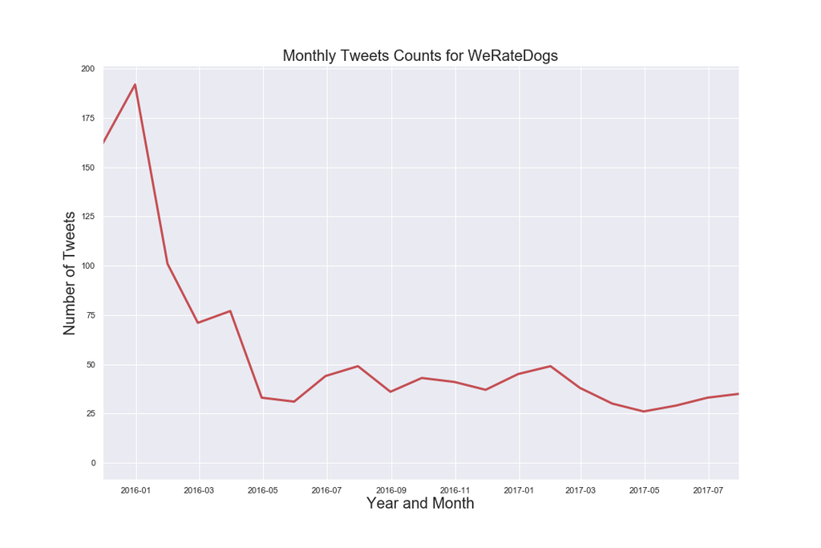

### The Top Ten Most Popular Dog Breeds

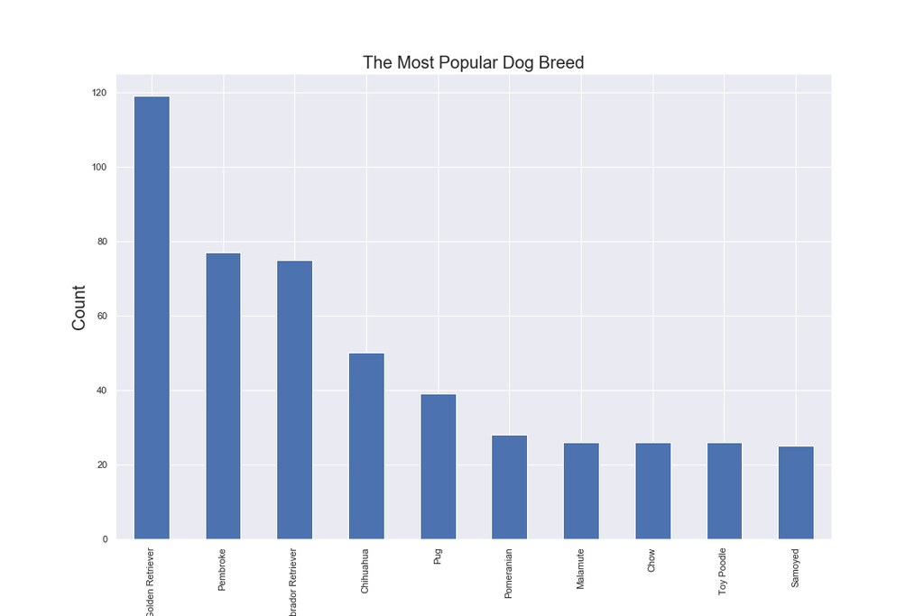

### The Most Popular Dog Category by Tweets Count

The most popular dog category according to the analysis carried out of the data was pupper, followed by doggo, then puppo and lastly fluffer which seemed to be way less popular compared to the other dog categories.

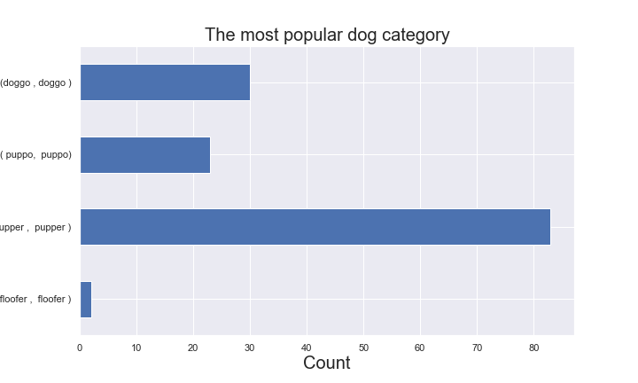

### The Most Popular Dog Category Based on the Average Retweet Count

Based on the average retweet count, the most popular dog category seemed to be the puppo, followed by the doggo, floofer and pupper.

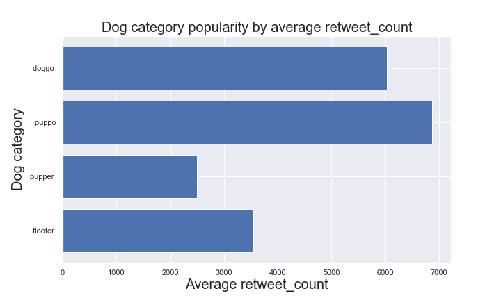

### The Dog Category with the Highest Number of Likes

The dog cateory that had the highest average number of likes after analysing the data was the puppo, then the floofer, doggo and pupper in decreasing order of average number of likes.

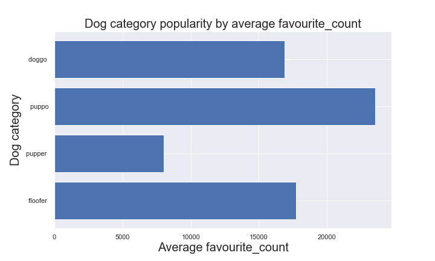

### Top 10 Dog Breeds with the Most Likes

The twitter data was analysed to show the Top 10 breeds of dogs with the most average likes. In other words, this showed the breeds of dogs that people seemed to like the most above other dog breeds. The Irish Water Spaniel seemed to be the most liked dog breed amongst all others closely followed by the Saluki dog breed.

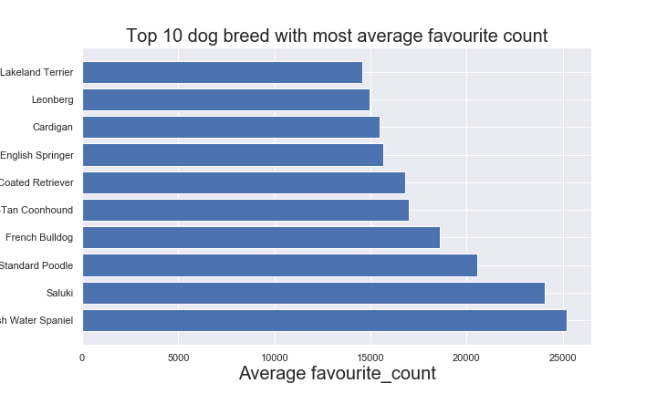

## Limitations of the study

The analysis and study of this data was limited due the facts that:

- Some columns such as the dog_category column had a lot of missing data that classified each dog as either puppo, floofer, pupper or doggo. It is possible that one of the categories had more missing data and so was disadvantaged during the analysis
- The data was last updated in August of 2017, which implies that trends may have changed but of course the data does not capture that because it is outdated.
- Some of the columns and rows that were dropped may have been used to get more insight to the data

Further analysis could be carried out to have insight on whether there is a relationship between the favourite count and rewteet count of the dataset, and whether certain dogs recieved more higher average favourite count at certain months of the year rather than the all through the years calculated at once.